# Gradient Descent Classifier

This notebook will demonstrate the process of training a binary classifier using gradient descent on a toy two-dimensional dataset.

First we will load the dataset.

```r
class1<-read.table("Class1.txt",header=TRUE,sep=",")
class1.dim<-dim(class1)
class1.label<-rep(1,class1.dim[1])
class1<-cbind(class1,class1.label)
names(class1)<-c("weight","height","label")
class1

class2<-read.table("Class2.txt",header=TRUE,sep=",")
class2.dim<-dim(class2)
class2.label<-rep(-1,class2.dim[1])
class2<-cbind(class2,class2.label)
names(class2)<-c("weight","height","label")
class2

class1.2<-rbind(class1,class2)
class1.2
```

| weight | height | label |
| --- | --- | --- |
| 0.132 | 0.757 | 1 |
| 0.722 | 0.888 | 1 |
| 0.095 | 0.804 | 1 |
| 0.633 | 0.530 | 1 |
| 0.472 | 0.701 | 1 |
| 0.294 | 0.183 | 1 |
| 0.179 | 0.874 | 1 |
| 0.023 | 0.664 | 1 |
| 0.116 | 0.978 | 1 |
| 0.054 | 0.786 | 1 |
| 0.394 | 0.970 | 1 |
| 0.165 | 0.372 | 1 |
| 0.654 | 0.906 | 1 |
| 0.486 | 0.871 | 1 |
| 0.237 | 0.691 | 1 |
| 0.584 | 0.990 | 1 |
| 0.133 | 0.396 | 1 |
| 0.068 | 0.234 | 1 |
| 0.114 | 0.464 | 1 |
| 0.108 | 0.241 | 1 |
| 0.392 | 0.697 | 1 |
| 0.049 | 0.361 | 1 |
| 0.169 | 0.877 | 1 |
| 0.709 | 0.863 | 1 |
| 0.046 | 0.646 | 1 |
| 0.069 | 0.525 | 1 |
| 0.432 | 0.841 | 1 |
| 0.366 | 0.888 | 1 |
| 0.386 | 0.570 | 1 |
| 0.576 | 0.912 | 1 |
| ... | ... | ... |
| 0.577 | 0.902 | 1 |
| 0.033 | 0.473 | 1 |
| 0.773 | 0.938 | 1 |
| 0.303 | 0.680 | 1 |
| 0.576 | 0.721 | 1 |
| 0.326 | 0.989 | 1 |
| 0.407 | 0.719 | 1 |
| 0.406 | 0.921 | 1 |
| 0.649 | 0.905 | 1 |
| 0.579 | 0.841 | 1 |
| 0.095 | 0.621 | 1 |
| 0.254 | 0.646 | 1 |
| 0.093 | 0.570 | 1 |
| 0.126 | 0.420 | 1 |
| 0.387 | 0.710 | 1 |
| 0.063 | 0.996 | 1 |
| 0.016 | 0.867 | 1 |
| 0.161 | 0.885 | 1 |
| 0.010 | 0.700 | 1 |
| 0.154 | 0.564 | 1 |
| 0.565 | 0.961 | 1 |
| 0.340 | 0.482 | 1 |
| 0.443 | 0.763 | 1 |
| 0.741 | 0.948 | 1 |
| 0.339 | 0.761 | 1 |
| 0.870 | 0.132 | 1 |
| 0.704 | 0.564 | 1 |
| 0.842 | 0.052 | 1 |
| 0.903 | 0.010 | 1 |
| 0.621 | 0.691 | 1 |

| weight | height | label |
| --- | --- | --- |
| 0.407 | 0.347 | -1 |
| 0.726 | 0.761 | -1 |
| 0.644 | 0.415 | -1 |
| 0.076 | 0.143 | -1 |
| 0.110 | 0.010 | -1 |
| 0.907 | 0.859 | -1 |
| 0.836 | 0.211 | -1 |
| 0.954 | 0.706 | -1 |
| 0.807 | 0.466 | -1 |
| 0.619 | 0.489 | -1 |
| 0.695 | 0.227 | -1 |
| 0.629 | 0.153 | -1 |
| 0.741 | 0.613 | -1 |
| 0.311 | 0.289 | -1 |
| 0.465 | 0.426 | -1 |
| 0.224 | 0.102 | -1 |
| 0.387 | 0.091 | -1 |
| 0.896 | 0.839 | -1 |
| 0.232 | 0.243 | -1 |
| 0.704 | 0.321 | -1 |
| 0.383 | 0.234 | -1 |
| 0.171 | 0.001 | -1 |
| 0.913 | 0.295 | -1 |
| 0.922 | 0.166 | -1 |
| 0.430 | 0.404 | -1 |
| 0.819 | 0.670 | -1 |
| 0.318 | 0.628 | -1 |
| 0.828 | 0.412 | -1 |
| 0.661 | 0.556 | -1 |
| 0.509 | 0.572 | -1 |
| ... | ... | ... |
| 0.129 | 0.123 | -1 |
| 0.876 | 0.342 | -1 |
| 0.481 | 0.567 | -1 |
| 0.909 | 0.804 | -1 |
| 0.721 | 0.837 | -1 |
| 0.662 | 0.772 | -1 |
| 0.796 | 0.566 | -1 |
| 0.900 | 0.032 | -1 |
| 0.702 | 0.386 | -1 |
| 0.887 | 0.003 | -1 |
| 0.634 | 0.377 | -1 |
| 0.686 | 0.329 | -1 |
| 0.532 | 0.630 | -1 |
| 0.495 | 0.394 | -1 |
| 0.633 | 0.706 | -1 |
| 0.217 | 0.330 | -1 |
| 0.999 | 0.726 | -1 |
| 0.945 | 0.274 | -1 |
| 0.935 | 0.321 | -1 |
| 0.213 | 0.012 | -1 |
| 0.165 | 0.014 | -1 |
| 0.781 | 0.607 | -1 |
| 0.902 | 0.957 | -1 |
| 0.868 | 0.201 | -1 |
| 0.198 | 0.006 | -1 |
| 0.052 | 0.385 | -1 |
| 0.433 | 0.986 | -1 |
| 0.357 | 0.554 | -1 |
| 0.303 | 0.889 | -1 |
| 0.061 | 0.814 | -1 |

| weight | height | label |
| --- | --- | --- |
| 0.132 | 0.757 | 1 |
| 0.722 | 0.888 | 1 |
| 0.095 | 0.804 | 1 |
| 0.633 | 0.530 | 1 |
| 0.472 | 0.701 | 1 |
| 0.294 | 0.183 | 1 |
| 0.179 | 0.874 | 1 |
| 0.023 | 0.664 | 1 |
| 0.116 | 0.978 | 1 |
| 0.054 | 0.786 | 1 |
| 0.394 | 0.970 | 1 |
| 0.165 | 0.372 | 1 |
| 0.654 | 0.906 | 1 |
| 0.486 | 0.871 | 1 |
| 0.237 | 0.691 | 1 |
| 0.584 | 0.990 | 1 |
| 0.133 | 0.396 | 1 |
| 0.068 | 0.234 | 1 |
| 0.114 | 0.464 | 1 |
| 0.108 | 0.241 | 1 |
| 0.392 | 0.697 | 1 |
| 0.049 | 0.361 | 1 |
| 0.169 | 0.877 | 1 |
| 0.709 | 0.863 | 1 |
| 0.046 | 0.646 | 1 |
| 0.069 | 0.525 | 1 |
| 0.432 | 0.841 | 1 |
| 0.366 | 0.888 | 1 |
| 0.386 | 0.570 | 1 |
| 0.576 | 0.912 | 1 |
| ... | ... | ... |
| 0.129 | 0.123 | -1 |
| 0.876 | 0.342 | -1 |
| 0.481 | 0.567 | -1 |
| 0.909 | 0.804 | -1 |
| 0.721 | 0.837 | -1 |
| 0.662 | 0.772 | -1 |
| 0.796 | 0.566 | -1 |
| 0.900 | 0.032 | -1 |
| 0.702 | 0.386 | -1 |
| 0.887 | 0.003 | -1 |
| 0.634 | 0.377 | -1 |
| 0.686 | 0.329 | -1 |
| 0.532 | 0.630 | -1 |
| 0.495 | 0.394 | -1 |
| 0.633 | 0.706 | -1 |
| 0.217 | 0.330 | -1 |
| 0.999 | 0.726 | -1 |
| 0.945 | 0.274 | -1 |
| 0.935 | 0.321 | -1 |
| 0.213 | 0.012 | -1 |
| 0.165 | 0.014 | -1 |
| 0.781 | 0.607 | -1 |
| 0.902 | 0.957 | -1 |
| 0.868 | 0.201 | -1 |
| 0.198 | 0.006 | -1 |
| 0.052 | 0.385 | -1 |
| 0.433 | 0.986 | -1 |
| 0.357 | 0.554 | -1 |
| 0.303 | 0.889 | -1 |
| 0.061 | 0.814 | -1 |

Next we will train the classifier. We will randomize the data, then use 80% of it to train the classifier, and 20% of it to test the classifier.

```r
d.set<-data.frame(cbind(rep(1,nrow(class1.2)),class1.2))
names(d.set)<-c("bias","weight","height","label")
samples<-sample(nrow(d.set))
randomized.set<-d.set[samples,]
randomized.set
```

|  | bias | weight | height | label |
| --- | --- | --- | --- | --- |
| 42 | 1 | 0.450 | 0.844 | 1 |
| 110 | 1 | 0.619 | 0.489 | -1 |
| 128 | 1 | 0.828 | 0.412 | -1 |
| 79 | 1 | 0.649 | 0.905 | 1 |
| 87 | 1 | 0.016 | 0.867 | 1 |
| 60 | 1 | 0.384 | 0.846 | 1 |
| 3 | 1 | 0.095 | 0.804 | 1 |
| 93 | 1 | 0.443 | 0.763 | 1 |
| 95 | 1 | 0.339 | 0.761 | 1 |
| 7 | 1 | 0.179 | 0.874 | 1 |
| 21 | 1 | 0.392 | 0.697 | 1 |
| 46 | 1 | 0.140 | 0.643 | 1 |
| 61 | 1 | 0.097 | 0.537 | 1 |
| 20 | 1 | 0.108 | 0.241 | 1 |
| 64 | 1 | 0.097 | 0.649 | 1 |
| 108 | 1 | 0.954 | 0.706 | -1 |
| 178 | 1 | 0.900 | 0.032 | -1 |
| 24 | 1 | 0.709 | 0.863 | 1 |
| 105 | 1 | 0.110 | 0.010 | -1 |
| 115 | 1 | 0.465 | 0.426 | -1 |
| 186 | 1 | 0.217 | 0.330 | -1 |
| 109 | 1 | 0.807 | 0.466 | -1 |
| 146 | 1 | 0.857 | 0.428 | -1 |
| 71 | 1 | 0.577 | 0.902 | 1 |
| 166 | 1 | 0.390 | 0.477 | -1 |
| 116 | 1 | 0.224 | 0.102 | -1 |
| 133 | 1 | 0.862 | 0.080 | -1 |
| 37 | 1 | 0.173 | 0.379 | 1 |
| 199 | 1 | 0.303 | 0.889 | -1 |
| 168 | 1 | 0.537 | 0.431 | -1 |
| ... | ... | ... | ... | ... |
| 196 | 1 | 0.052 | 0.385 | -1 |
| 19 | 1 | 0.114 | 0.464 | 1 |
| 189 | 1 | 0.935 | 0.321 | -1 |
| 54 | 1 | 0.423 | 0.956 | 1 |
| 85 | 1 | 0.387 | 0.710 | 1 |
| 45 | 1 | 0.229 | 0.984 | 1 |
| 195 | 1 | 0.198 | 0.006 | -1 |
| 113 | 1 | 0.741 | 0.613 | -1 |
| 174 | 1 | 0.909 | 0.804 | -1 |
| 55 | 1 | 0.638 | 0.911 | 1 |
| 138 | 1 | 0.677 | 0.140 | -1 |
| 129 | 1 | 0.661 | 0.556 | -1 |
| 161 | 1 | 0.205 | 0.325 | -1 |
| 164 | 1 | 0.897 | 0.993 | -1 |
| 15 | 1 | 0.237 | 0.691 | 1 |
| 193 | 1 | 0.902 | 0.957 | -1 |
| 5 | 1 | 0.472 | 0.701 | 1 |
| 148 | 1 | 0.904 | 0.941 | -1 |
| 160 | 1 | 0.842 | 0.102 | -1 |
| 97 | 1 | 0.704 | 0.564 | 1 |
| 49 | 1 | 0.219 | 0.628 | 1 |
| 53 | 1 | 0.575 | 0.724 | 1 |
| 89 | 1 | 0.010 | 0.700 | 1 |
| 69 | 1 | 0.626 | 0.782 | 1 |
| 57 | 1 | 0.057 | 0.940 | 1 |
| 102 | 1 | 0.726 | 0.761 | -1 |
| 65 | 1 | 0.056 | 0.615 | 1 |
| 134 | 1 | 0.856 | 0.622 | -1 |
| 135 | 1 | 0.916 | 0.075 | -1 |
| 132 | 1 | 0.710 | 0.347 | -1 |

With the randomizing complete, we provide the gradient descent learning algorithm:

```r
Gradient.Descent.Learning <- function(x, eta, niter, threshold) {

  # initialize weight vector
  #weight <- rep(0.1, dim(x)[2]-1)
  weight<-runif(dim(x)[2]-1,-1,1)
  errors <- rep(0, niter)
  label.index<-length(x[1,])
  features<-x[,-label.index]
  labels<-x[,label.index]

  # loop over number of epochs niter
  jj<-1
  err.value<-10
  while(jj<niter && err.value>threshold){
    delta.weight<-rep(0,dim(x)[2]-1)
    # loop through training data set
    squared.error<-0
    for (ii in 1:nrow(x))
    {
      # Prediction
      z <- sum(weight[1:length(weight)] * as.numeric(features[ii,]))
      weightdiff <- eta * (as.numeric(labels[ii]) - z) * as.numeric(features[ii,])
      delta.weight <- delta.weight + weightdiff

      # update error rate
      squared.error<-squared.error+(as.numeric(labels[ii])-z)*(as.numeric(labels[ii])-z)
    }
    errors[jj]<-squared.error/nrow(x)/2
    err.value<-errors[jj]
    weight<-weight + delta.weight/nrow(x)
    jj<-jj+1
  }

  # weight to decide between the two species
  print(weight)
  print(errors)
  return(list(v1=weight,v2=errors))
}
```

Then we perform the 80-20 split described above and execute the training:

```r
set.seed(1)
train<-sample(1:nrow(randomized.set), 0.8*nrow(randomized.set))
train.set<-randomized.set[train,]
test.set<-randomized.set[-train,]

iterations<-2000
weight.err<-Gradient.Descent.Learning(train.set, 0.05, iterations, 0.1)
```

```
[1] -0.1278241 -1.6425661  1.6273647
   [1] 1.4711530 1.3538647 1.2532839 1.1669730 1.0928502 1.0291382 0.9743191
   [8] 0.9270967 0.8863644 0.8511771 0.8207277 0.7943272 0.7713871 0.7514049
  [15] 0.7339515 0.7186603 0.7052186 0.6933590 0.6828534 0.6735069 0.6651530
  [22] 0.6576496 0.6508753 0.6447264 0.6391144 0.6339636 0.6292094 0.6247966
  [29] 0.6206781 0.6168136 0.6131687 0.6097139 0.6064242 0.6032780 0.6002571
  [36] 0.5973456 0.5945301 0.5917993 0.5891432 0.5865534 0.5840228 0.5815452
  [43] 0.5791152 0.5767284 0.5743809 0.5720692 0.5697907 0.5675427 0.5653232
  [50] 0.5631302 0.5609624 0.5588182 0.5566964 0.5545962 0.5525164 0.5504564
  [57] 0.5484155 0.5463931 0.5443886 0.5424016 0.5404316 0.5384783 0.5365413
  [64] 0.5346204 0.5327152 0.5308255 0.5289511 0.5270918 0.5252474 0.5234176
  [71] 0.5216023 0.5198014 0.5180146 0.5162420 0.5144832 0.5127382 0.5110068
  [78] 0.5092890 0.5075846 0.5058934 0.5042154 0.5025505 0.5008985 0.4992593
  [85] 0.4976329 0.4960191 0.4944178 0.4928289 0.4912524 0.4896881 0.4881359
  [92] 0.4865957 0.4850675 0.4835511 0.4820465 0.4805535 0.4790721 0.4776021
```

[output cut: 272 more lines]

```r
weight.err
```

1. -0.127824083101231

2. -1.64256613721373

3. 1.62736471106522

2. 1.35386468435713

3. 1.25328392971455

4. 1.16697298797078

5. 1.0928502483843

6. 1.02913821086022

7. 0.974319053701989

8. 0.927096693187871

9. 0.886364386476434

10. 0.85117706792644

11. 0.820727727250005

12. 0.794327238962192

13. 0.771387138871307

14. 0.751404917029034

15. 0.733951459470058

16. 0.718660324789766

17. 0.705218587478847

18. 0.693359019101907

19. 0.682853411852854

20. 0.67350687757873

21. 0.66515297975003

22. 0.657649576678901

23. 0.650875272067492

24. 0.644726384151795

25. 0.639114357670972

26. 0.633963553962623

27. 0.629209363937496

28. 0.624796596758933

29. 0.620678103944915

30. 0.616813604496014

31. 0.613168681678133

32. 0.609713926380215

33. 0.606424205631424

34. 0.603278037991236

35. 0.600257060197654

36. 0.597345571740184

37. 0.59453014597228

38. 0.591799298041464

39. 0.589143201335689

40. 0.586553445357446

41. 0.584022828972778

42. 0.581545183866706

43. 0.579115223791744

44. 0.576728415840966

45. 0.574380870527735

46. 0.572069247924315

47. 0.569790677513064

48. 0.567542689746765

49. 0.56532315760727

50. 0.563130246701698

51. 0.560962372648778

52. 0.558818164690224

53. 0.556696434617624

54. 0.554596150238236

55. 0.552516412716525

56. 0.550456437225177

57. 0.548415536422088

58. 0.546393106340399

59. 0.544388614339077

60. 0.542401588812949

61. 0.540431610405147

62. 0.538478304502467

63. 0.536541334826192

64. 0.53462039795835

65. 0.532715218666723

66. 0.530825545911933

67. 0.528951149436936

68. 0.527091816853858

69. 0.525247351155497

70. 0.523417568589469

71. 0.521602296842008

72. 0.519801373486191

73. 0.518014644655964

74. 0.516241963912975

75. 0.514483191278059

76. 0.512738192403331

77. 0.511006837864328

78. 0.5092890025547

79. 0.507584565168439

80. 0.505893407756894

81. 0.504215415349626

82. 0.502550475629804

83. 0.500898478656163

84. 0.499259316624742

85. 0.497632883664583

86. 0.496019075662443

87. 0.494417790112292

88. 0.492828925985969

89. 0.491252383621916

90. 0.489688064629364

91. 0.488135871805711

92. 0.486595709065165

93. 0.485067481377026

94. 0.483551094712202

95. 0.482046455996746

96. 0.480553473071422

97. 0.479072054656393

98. 0.477602110320326

99. 0.476143550453231

100. 0.474696286242539

101. 0.473260229651916

102. 0.471835293402432

103. 0.470421390955763

104. 0.469018436499101

105. 0.467626344931557

106. 0.46624503185183

107. 0.464874413546971

108. 0.463514406982075

109. 0.462164929790787

110. 0.460825900266498

111. 0.459497237354129

112. 0.458178860642451

113. 0.456870690356828

114. 0.455572647352358

115. 0.454284653107347

116. 0.453006629717069

117. 0.451738499887786

118. 0.450480186930983

119. 0.449231614757803

120. 0.447992707873645

121. 0.446763391372926

122. 0.445543590933958

123. 0.444333232813964

124. 0.443132243844186

125. 0.441940551425095

126. 0.44075808352169

127. 0.439584768658866

128. 0.438420535916867

129. 0.437265314926793

130. 0.43611903586618

131. 0.434981629454623

132. 0.433853026949466

133. 0.432733160141532

134. 0.431621961350905

135. 0.430519363422753

136. 0.429425299723198

137. 0.428339704135226

138. 0.427262511054628

139. 0.426193655385995

140. 0.425133072538732

141. 0.424080698423119

142. 0.423036469446404

143. 0.422000322508927

144. 0.420972195000279

145. 0.419952024795494

146. 0.418939750251271

147. 0.417935310202227

148. 0.416938643957184

149. 0.415949691295479

150. 0.414968392463313

151. 0.413994688170121

152. 0.413028519584977

153. 0.412069828333024

154. 0.411118556491932

155. 0.410174646588389

156. 0.40923804159461

157. 0.408308684924888

158. 0.407386520432154

159. 0.406471492404581

160. 0.405563545562205

161. 0.404662625053572

162. 0.403768676452415

163. 0.402881645754358

164. 0.402001479373641

165. 0.401128124139872

166. 0.400261527294808

167. 0.399401636489154

168. 0.398548399779398

169. 0.397701765624655

170. 0.396861682883549

171. 0.396028100811114

172. 0.395200969055722

173. 0.394380237656027

174. 0.393565857037941

175. 0.392757778011631

176. 0.391955951768538

177. 0.391160329878421

178. 0.390370864286421

179. 0.389587507310152

180. 0.388810211636812

181. 0.388038930320315

182. 0.38727361677845

183. 0.386514224790055

184. 0.385760708492221

185. 0.385013022377513

186. 0.384271121291211

187. 0.383534960428576

188. 0.382804495332136

189. 0.382079681888995

190. 0.381360476328155

191. 0.380646835217872

192. 0.37993871546302

193. 0.379236074302481

194. 0.378538869306559

195. 0.377847058374403

196. 0.377160599731465

197. 0.37647945192696

198. 0.375803573831367

199. 0.375132924633925

200. 0.374467463840172

201. 0.373807151269486

202. 0.373151947052654

203. 0.372501811629453

204. 0.37185670574626

205. 0.371216590453673

206. 0.370581427104145

207. 0.369951177349654

208. 0.369325803139372

209. 0.368705266717365

210. 0.368089530620303

211. 0.367478557675196

212. 0.366872310997137

213. 0.36627075398707

214. 0.365673850329574

215. 0.365081563990667

216. 0.364493859215616

217. 0.363910700526778

218. 0.363332052721448

219. 0.362757880869731

220. 0.36218815031242

221. 0.361622826658904

222. 0.36106187578508

223. 0.360505263831292

224. 0.359952957200275

225. 0.359404922555121

226. 0.358861126817266

227. 0.358321537164479

228. 0.35778612102888

229. 0.357254846094965

230. 0.356727680297651

231. 0.356204591820332

232. 0.355685549092954

233. 0.355170520790103

234. 0.354659475829108

235. 0.354152383368159

236. 0.35364921280444

237. 0.353149933772272

238. 0.352654516141282

239. 0.352162930014571

240. 0.351675145726907

241. 0.35119113384293

242. 0.350710865155366

243. 0.350234310683264

244. 0.349761441670234

245. 0.349292229582713

246. 0.348826646108232

247. 0.348364663153706

248. 0.347906252843728

249. 0.347451387518888

250. 0.34700003973409

251. 0.346552182256899

252. 0.346107788065885

253. 0.345666830348993

254. 0.345229282501913

255. 0.344795118126477

256. 0.344364311029055

257. 0.343936835218969

258. 0.343512664906925

259. 0.343091774503447

260. 0.342674138617327

261. 0.342259732054092

262. 0.341848529814476

263. 0.341440507092906

264. 0.341035639276003

265. 0.34063390194109

266. 0.340235270854712

267. 0.339839721971172

268. 0.339447231431075

269. 0.339057775559882

270. 0.338671330866477

271. 0.338287874041747

272. 0.337907381957168

273. 0.337529831663408

274. 0.337155200388936

275. 0.336783465538644

276. 0.336414604692478

277. 0.336048595604083

278. 0.335685416199456

279. 0.335325044575608

280. 0.334967458999241

281. 0.334612637905429

282. 0.334260559896317

283. 0.333911203739823

284. 0.333564548368352

285. 0.333220572877523

286. 0.332879256524903

287. 0.332540578728752

288. 0.332204519066776

289. 0.331871057274892

290. 0.331540173246002

291. 0.331211847028774

292. 0.330886058826436

293. 0.330562788995577

294. 0.330242018044962

295. 0.329923726634344

296. 0.329607895573303

297. 0.329294505820077

298. 0.328983538480415

299. 0.328674974806429

300. 0.328368796195465

301. 0.328064984188971

302. 0.327763520471383

303. 0.327464386869017

304. 0.32716756534897

305. 0.326873038018025

306. 0.326580787121572

307. 0.32629079504253

308. 0.326003044300285

309. 0.325717517549631

310. 0.325434197579716

311. 0.325153067313007

312. 0.324874109804252

313. 0.324597308239459

314. 0.324322645934872

315. 0.324050106335967

316. 0.32377967301645

317. 0.32351132967726

318. 0.323245060145585

319. 0.322980848373882

320. 0.322718678438907

321. 0.322458534540753

322. 0.322200401001891

323. 0.321944262266223

324. 0.321690102898139

325. 0.321437907581589

326. 0.321187661119147

327. 0.320939348431099

328. 0.320692954554528

329. 0.320448464642408

330. 0.320205863962708

331. 0.319965137897498

332. 0.319726271942066

333. 0.31948925170404

334. 0.319254062902519

335. 0.319020691367208

336. 0.318789123037556

337. 0.318559343961915

338. 0.318331340296688

339. 0.318105098305495

340. 0.317880604358341

341. 0.317657844930791

342. 0.317436806603154

343. 0.317217476059669

344. 0.3169998400877

345. 0.316783885576937

346. 0.316569599518604

347. 0.316356969004668

348. 0.316145981227066

349. 0.31593662347692

350. 0.315728883143778

351. 0.315522747714844

352. 0.315318204774227

353. 0.315115242002183

354. 0.314913847174376

355. 0.314714008161139

356. 0.314515712926733

357. 0.314318949528625

358. 0.314123706116768

359. 0.313929970932876

360. 0.31373773230972

361. 0.31354697867042

362. 0.313357698527744

363. 0.313169880483413

364. 0.312983513227414

365. 0.312798585537314

366. 0.312615086277582

367. 0.312433004398916

368. 0.312252328937571

369. 0.312073049014704

370. 0.311895153835707

371. 0.311718632689559

372. 0.31154347494818

373. 0.311369670065783

374. 0.311197207578241

375. 0.311026077102451

376. 0.310856268335708

377. 0.310687771055081

378. 0.310520575116796

379. 0.310354670455621

380. 0.310190047084259

381. 0.310026695092742

382. 0.309864604647834

383. 0.309703765992434

384. 0.30954416944499

385. 0.309385805398909

386. 0.309228664321978

387. 0.309072736755788

388. 0.308918013315162

389. 0.308764484687589

390. 0.308612141632656

391. 0.308460974981495

392. 0.308310975636226

393. 0.308162134569408

394. 0.308014442823489

395. 0.307867891510271

396. 0.30772247181037

397. 0.307578174972678

398. 0.307434992313844

399. 0.307292915217737

400. 0.307151935134937

401. 0.307012043582209

402. 0.306873232141994

403. 0.306735492461901

404. 0.306598816254199

405. 0.30646319529532

406. 0.306328621425357

407. 0.306195086547576

408. 0.306062582627921

409. 0.305931101694534

410. 0.305800635837269

411. 0.305671177207215

412. 0.305542718016223

413. 0.305415250536431

414. 0.305288767099805

415. 0.305163260097665

416. 0.305038721980232

417. 0.304915145256173

418. 0.304792522492141

419. 0.304670846312335

420. 0.304550109398043

421. 0.30443030448721

422. 0.304311424373995

423. 0.304193461908334

424. 0.304076409995509

425. 0.303960261595721

426. 0.30384500972366

427. 0.303730647448091

428. 0.303617167891424

429. 0.303504564229309

430. 0.303392829690215

431. 0.303281957555028

432. 0.30317194115664

433. 0.303062773879546

434. 0.302954449159449

435. 0.302846960482858

436. 0.302740301386697

437. 0.302634465457914

438. 0.302529446333095

439. 0.302425237698074

440. 0.302321833287559

441. 0.302219226884749

442. 0.302117412320959

443. 0.302016383475246

444. 0.301916134274041

445. 0.301816658690784

446. 0.301717950745554

447. 0.301620004504713

448. 0.301522814080546

449. 0.301426373630902

450. 0.301330677358847

451. 0.301235719512309

452. 0.301141494383732

453. 0.301047996309732

454. 0.300955219670754

455. 0.300863158890731

456. 0.30077180843675

457. 0.300681162818718

458. 0.300591216589023

459. 0.300501964342218

460. 0.300413400714682

461. 0.300325520384303

462. 0.300238318070154

463. 0.300151788532173

464. 0.300065926570852

465. 0.299980727026914

466. 0.29989618478101

467. 0.299812294753404

468. 0.299729051903668

469. 0.299646451230379

470. 0.299564487770815

471. 0.299483156600654

472. 0.29940245283368

473. 0.299322371621488

474. 0.299242908153185

475. 0.299164057655106

476. 0.299085815390525

477. 0.299008176659365

478. 0.298931136797917

479. 0.298854691178558

480. 0.298778835209472

481. 0.29870356433437

482. 0.29862887403222

483. 0.298554759816967

484. 0.298481217237268

485. 0.298408241876222

486. 0.298335829351099

487. 0.298263975313081

488. 0.298192675446997

489. 0.298121925471061

490. 0.298051721136616

491. 0.297982058227876

492. 0.297912932561671

493. 0.297844339987196

494. 0.297776276385758

495. 0.29770873767053

496. 0.297641719786303

497. 0.29757521870924

498. 0.297509230446635

499. 0.29744375103667

500. 0.297378776548178

501. 0.297314303080405

502. 0.297250326762771

503. 0.297186843754641

504. 0.297123850245094

505. 0.297061342452685

506. 0.296999316625226

507. 0.296937769039554

508. 0.296876696001307

509. 0.296816093844703

510. 0.296755958932315

511. 0.296696287654858

512. 0.296637076430963

513. 0.296578321706964

514. 0.296520019956689

515. 0.296462167681236

516. 0.296404761408774

517. 0.296347797694321

518. 0.296291273119549

519. 0.296235184292567

520. 0.296179527847721

521. 0.296124300445392

522. 0.29606949877179

523. 0.296015119538758

524. 0.295961159483573

525. 0.295907615368748

526. 0.295854483981834

527. 0.295801762135233

528. 0.295749446666

529. 0.295697534435651

530. 0.295646022329981

531. 0.295594907258868

532. 0.29554418615609

533. 0.295493855979141

534. 0.295443913709046

535. 0.295394356350177

536. 0.295345180930077

537. 0.295296384499276

538. 0.295247964131114

539. 0.295199916921567

540. 0.295152239989069

541. 0.295104930474339

542. 0.29505798554021

543. 0.295011402371454

544. 0.294965178174615

545. 0.29491931017784

546. 0.294873795630714

547. 0.294828631804088

548. 0.294783815989919

549. 0.294739345501108

550. 0.294695217671332

551. 0.294651429854889

552. 0.294607979426535

553. 0.294564863781327

554. 0.294522080334465

555. 0.294479626521137

556. 0.294437499796363

557. 0.294395697634844

558. 0.294354217530805

559. 0.294313056997849

560. 0.294272213568803

561. 0.294231684795573

562. 0.294191468248994

563. 0.29415156151868

564. 0.294111962212887

565. 0.294072667958362

566. 0.294033676400201

567. 0.293994985201708

568. 0.293956592044257

569. 0.293918494627143

570. 0.293880690667456

571. 0.293843177899931

572. 0.293805954076819

573. 0.293769016967751

574. 0.293732364359599

575. 0.293695994056348

576. 0.293659903878957

577. 0.293624091665236

578. 0.293588555269709

579. 0.293553292563485

580. 0.293518301434134

581. 0.293483579785557

582. 0.293449125537857

583. 0.293414936627218

584. 0.293381011005777

585. 0.293347346641505

586. 0.29331394151808

587. 0.293280793634765

588. 0.293247901006292

589. 0.29321526166274

590. 0.293182873649413

591. 0.293150735026729

592. 0.293118843870095

593. 0.293087198269799

594. 0.293055796330887

595. 0.293024636173055

596. 0.292993715930533

597. 0.292963033751973

598. 0.292932587800338

599. 0.292902376252787

600. 0.292872397300571

601. 0.292842649148923

602. 0.292813130016946

603. 0.292783838137508

604. 0.292754771757136

605. 0.292725929135911

606. 0.292697308547359

607. 0.292668908278353

608. 0.292640726629004

609. 0.292612761912561

610. 0.292585012455312

611. 0.292557476596478

612. 0.292530152688116

613. 0.29250303909502

614. 0.292476134194619

615. 0.292449436376885

616. 0.292422944044231

617. 0.292396655611416

618. 0.292370569505451

619. 0.292344684165501

620. 0.292318998042796

621. 0.292293509600533

622. 0.292268217313784

623. 0.292243119669407

624. 0.292218215165952

625. 0.292193502313571

626. 0.292168979633931

627. 0.29214464566012

628. 0.292120498936563

629. 0.29209653801893

630. 0.292072761474055

631. 0.292049167879844

632. 0.292025755825192

633. 0.292002523909897

634. 0.291979470744576

635. 0.291956594950584

636. 0.291933895159923

637. 0.291911370015171

638. 0.291889018169389

639. 0.291866838286047

640. 0.291844829038943

641. 0.29182298911212

642. 0.291801317199787

643. 0.291779812006244

644. 0.2917584722458

645. 0.291737296642698

646. 0.291716283931038

647. 0.291695432854697

648. 0.29167474216726

649. 0.291654210631938

650. 0.2916338370215

651. 0.291613620118193

652. 0.291593558713674

653. 0.291573651608934

654. 0.291553897614224

655. 0.291534295548989

656. 0.291514844241793

657. 0.29149554253025

658. 0.291476389260949

659. 0.291457383289396

660. 0.291438523479931

661. 0.29141980870567

662. 0.291401237848434

663. 0.291382809798679

664. 0.291364523455433

665. 0.291346377726227

666. 0.291328371527032

667. 0.291310503782191

668. 0.291292773424356

669. 0.291275179394422

670. 0.291257720641465

671. 0.291240396122679

672. 0.29122320480331

673. 0.291206145656598

674. 0.291189217663712

675. 0.29117241981369

676. 0.291155751103378

677. 0.291139210537369

678. 0.291122797127945

679. 0.291106509895016

680. 0.291090347866059

681. 0.291074310076065

682. 0.291058395567473

683. 0.291042603390122

684. 0.291026932601185

685. 0.291011382265118

686. 0.2909959514536

687. 0.29098063924548

688. 0.29096544472672

689. 0.29095036699034

690. 0.290935405136364

691. 0.290920558271765

692. 0.290905825510414

693. 0.290891205973021

694. 0.290876698787089

695. 0.290862303086855

696. 0.290848018013243

697. 0.29083384271381

698. 0.290819776342694

699. 0.290805818060565

700. 0.290791967034573

701. 0.290778222438299

702. 0.290764583451705

703. 0.290751049261084

704. 0.29073761905901

705. 0.290724292044293

706. 0.290711067421928

707. 0.290697944403046

708. 0.290684922204873

709. 0.290672000050672

710. 0.290659177169708

711. 0.290646452797192

712. 0.290633826174243

713. 0.290621296547836

714. 0.29060886317076

715. 0.290596525301571

716. 0.29058428220455

717. 0.290572133149658

718. 0.29056007741249

719. 0.290548114274234

720. 0.290536243021625

721. 0.290524462946907

722. 0.290512773347784

723. 0.290501173527382

724. 0.290489662794207

725. 0.290478240462101

726. 0.290466905850205

727. 0.29045565828291

728. 0.290444497089828

729. 0.290433421605741

730. 0.290422431170567

731. 0.290411525129317

732. 0.29040070283206

733. 0.290389963633879

734. 0.290379306894836

735. 0.29036873197993

736. 0.290358238259061

737. 0.290347825106994

738. 0.290337491903317

739. 0.290327238032407

740. 0.290317062883392

741. 0.290306965850114

742. 0.290296946331092

743. 0.290287003729489

744. 0.29027713745307

745. 0.290267346914173

746. 0.290257631529671

747. 0.290247990720935

748. 0.290238423913803

749. 0.29022893053854

750. 0.290219510029811

751. 0.290210161826642

752. 0.290200885372386

753. 0.290191680114695

754. 0.290182545505477

755. 0.290173481000874

756. 0.290164486061223

757. 0.290155560151023

758. 0.290146702738906

759. 0.290137913297604

760. 0.290129191303917

761. 0.29012053623868

762. 0.290111947586736

763. 0.2901034248369

764. 0.290094967481933

765. 0.290086575018506

766. 0.290078246947176

767. 0.290069982772353

768. 0.290061782002267

769. 0.290053644148946

770. 0.290045568728179

771. 0.290037555259492

772. 0.290029603266115

773. 0.29002171227496

774. 0.290013881816585

775. 0.29000611142517

776. 0.289998400638487

777. 0.289990748997877

778. 0.289983156048214

779. 0.289975621337886

780. 0.289968144418764

781. 0.289960724846174

782. 0.289953362178871

783. 0.289946055979018

784. 0.289938805812148

785. 0.289931611247151

786. 0.289924471856239

787. 0.289917387214923

788. 0.289910356901989

789. 0.289903380499471

790. 0.289896457592627

791. 0.289889587769911

792. 0.289882770622955

793. 0.289876005746537

794. 0.289869292738561

795. 0.289862631200031

796. 0.289856020735029

797. 0.289849460950689

798. 0.289842951457176

799. 0.289836491867659

800. 0.289830081798291

801. 0.289823720868186

802. 0.289817408699392

803. 0.289811144916873

804. 0.289804929148485

805. 0.289798761024954

806. 0.28979264017985

807. 0.289786566249572

808. 0.289780538873321

809. 0.289774557693078

810. 0.289768622353588

811. 0.289762732502331

812. 0.289756887789507

813. 0.289751087868013

814. 0.289745332393421

815. 0.289739621023958

816. 0.289733953420487

817. 0.289728329246486

818. 0.289722748168024

819. 0.289717209853747

820. 0.289711713974855

821. 0.289706260205081

822. 0.289700848220676

823. 0.289695477700385

824. 0.289690148325426

825. 0.28968485977948

826. 0.289679611748663

827. 0.289674403921511

828. 0.28966923598896

829. 0.289664107644329

830. 0.2896590185833

831. 0.289653968503902

832. 0.289648957106489

833. 0.289643984093727

834. 0.289639049170573

835. 0.289634152044255

836. 0.289629292424261

837. 0.289624470022317

838. 0.289619684552369

839. 0.28961493573057

840. 0.289610223275257

841. 0.289605546906941

842. 0.289600906348284

843. 0.289596301324089

844. 0.289591731561275

845. 0.289587196788867

846. 0.28958269673798

847. 0.289578231141799

848. 0.289573799735565

849. 0.289569402256559

850. 0.289565038444086

851. 0.289560708039462

852. 0.289556410785993

853. 0.289552146428965

854. 0.289547914715624

855. 0.289543715395167

856. 0.28953954821872

857. 0.289535412939328

858. 0.289531309311938

859. 0.289527237093385

860. 0.289523196042377

861. 0.289519185919483

862. 0.289515206487112

863. 0.289511257509509

864. 0.289507338752731

865. 0.289503449984637

866. 0.289499590974877

867. 0.289495761494874

868. 0.289491961317811

869. 0.289488190218617

870. 0.28948444797396

871. 0.289480734362222

872. 0.289477049163495

873. 0.289473392159564

874. 0.289469763133896

875. 0.289466161871625

876. 0.289462588159538

877. 0.289459041786067

878. 0.289455522541272

879. 0.28945203021683

880. 0.289448564606022

881. 0.289445125503721

882. 0.289441712706381

883. 0.289438326012022

884. 0.289434965220221

885. 0.289431630132096

886. 0.289428320550298

887. 0.289425036278999

888. 0.289421777123876

889. 0.289418542892104

890. 0.289415333392343

891. 0.289412148434725

892. 0.289408987830846

893. 0.28940585139375

894. 0.289402738937924

895. 0.289399650279279

896. 0.289396585235147

897. 0.289393543624264

898. 0.289390525266763

899. 0.289387529984161

900. 0.289384557599351

901. 0.289381607936585

902. 0.289378680821472

903. 0.289375776080963

904. 0.289372893543339

905. 0.289370033038206

906. 0.289367194396479

907. 0.289364377450376

908. 0.289361582033406

909. 0.289358807980359

910. 0.289356055127299

911. 0.289353323311549

912. 0.289350612371684

913. 0.289347922147526

914. 0.289345252480124

915. 0.289342603211754

916. 0.289339974185906

917. 0.289337365247272

918. 0.28933477624174

919. 0.289332207016387

920. 0.289329657419464

921. 0.289327127300391

922. 0.289324616509745

923. 0.289322124899255

924. 0.289319652321791

925. 0.289317198631354

926. 0.289314763683068

927. 0.289312347333174

928. 0.289309949439017

929. 0.289307569859041

930. 0.28930520845278

931. 0.289302865080846

932. 0.289300539604926

933. 0.28929823188777

934. 0.289295941793184

935. 0.289293669186023

936. 0.28929141393218

937. 0.289289175898582

938. 0.289286954953177

939. 0.289284750964931

940. 0.289282563803818

941. 0.28928039334081

942. 0.289278239447875

943. 0.289276101997963

944. 0.289273980865003

945. 0.289271875923894

946. 0.289269787050496

947. 0.289267714121623

948. 0.289265657015041

949. 0.28926361560945

950. 0.289261589784489

951. 0.289259579420719

952. 0.28925758439962

953. 0.289255604603584

954. 0.289253639915909

955. 0.289251690220787

956. 0.289249755403306

957. 0.289247835349432

958. 0.289245929946011

959. 0.28924403908076

960. 0.289242162642257

961. 0.289240300519938

962. 0.289238452604091

963. 0.289236618785843

964. 0.289234798957164

965. 0.28923299301085

966. 0.289231200840523

967. 0.289229422340623

968. 0.289227657406403

969. 0.28922590593392

970. 0.289224167820028

971. 0.289222442962378

972. 0.289220731259406

973. 0.289219032610328

974. 0.289217346915137

975. 0.289215674074593

976. 0.28921401399022

977. 0.289212366564297

978. 0.289210731699858

979. 0.289209109300679

980. 0.289207499271276

981. 0.289205901516902

982. 0.289204315943534

983. 0.289202742457875

984. 0.289201180967344

985. 0.28919963138007

986. 0.289198093604892

987. 0.289196567551345

988. 0.289195053129663

989. 0.289193550250769

990. 0.289192058826269

991. 0.289190578768449

992. 0.289189109990271

993. 0.289187652405364

994. 0.28918620592802

995. 0.289184770473192

996. 0.289183345956485

997. 0.289181932294153

998. 0.289180529403093

999. 0.289179137200841

1000. 0.289177755605567

1001. 0.289176384536069

1002. 0.289175023911769

1003. 0.289173673652708

1004. 0.289172333679543

1005. 0.289171003913538

1006. 0.289169684276564

1007. 0.28916837469109

1008. 0.289167075080184

1009. 0.289165785367502

1010. 0.289164505477288

1011. 0.289163235334367

1012. 0.289161974864141

1013. 0.289160723992589

1014. 0.289159482646253

1015. 0.289158250752242

1016. 0.289157028238226

1017. 0.289155815032429

1018. 0.289154611063626

1019. 0.28915341626114

1020. 0.289152230554837

1021. 0.289151053875121

1022. 0.28914988615293

1023. 0.289148727319733

1024. 0.289147577307526

1025. 0.289146436048827

1026. 0.289145303476671

1027. 0.289144179524608

1028. 0.289143064126699

1029. 0.28914195721751

1030. 0.289140858732111

1031. 0.289139768606069

1032. 0.289138686775447

1033. 0.289137613176798

1034. 0.289136547747162

1035. 0.289135490424065

1036. 0.289134441145508

1037. 0.289133399849972

1038. 0.289132366476409

1039. 0.289131340964239

1040. 0.289130323253348

1041. 0.289129313284083

1042. 0.28912831099725

1043. 0.289127316334107

1044. 0.289126329236365

1045. 0.289125349646182

1046. 0.28912437750616

1047. 0.289123412759341

1048. 0.289122455349205

1049. 0.289121505219664

1050. 0.289120562315064

1051. 0.289119626580175

1052. 0.289118697960193

1053. 0.289117776400731

1054. 0.289116861847824

1055. 0.289115954247919

1056. 0.289115053547873

1057. 0.289114159694952

1058. 0.289113272636829

1059. 0.289112392321572

1060. 0.289111518697655

1061. 0.289110651713943

1062. 0.289109791319693

1063. 0.289108937464554

1064. 0.289108090098559

1065. 0.289107249172126

1066. 0.289106414636054

1067. 0.289105586441516

1068. 0.289104764540063

1069. 0.289103948883616

1070. 0.289103139424466

1071. 0.289102336115269

1072. 0.289101538909045

1073. 0.289100747759173

1074. 0.289099962619392

1075. 0.289099183443793

1076. 0.289098410186821

1077. 0.289097642803271

1078. 0.289096881248282

1079. 0.28909612547734

1080. 0.289095375446271

1081. 0.289094631111239

1082. 0.289093892428747

1083. 0.289093159355628

1084. 0.289092431849049

1085. 0.289091709866504

1086. 0.289090993365813

1087. 0.28909028230512

1088. 0.289089576642889

1089. 0.289088876337904

1090. 0.289088181349265

1091. 0.289087491636382

1092. 0.289086807158982

1093. 0.289086127877095

1094. 0.289085453751063

1095. 0.289084784741528

1096. 0.289084120809435

1097. 0.289083461916028

1098. 0.28908280802285

1099. 0.289082159091736

1100. 0.289081515084816

1101. 0.289080875964509

1102. 0.289080241693521

1103. 0.289079612234848

1104. 0.289078987551764

1105. 0.289078367607829

1106. 0.28907775236688

1107. 0.289077141793032

1108. 0.289076535850675

1109. 0.289075934504471

1110. 0.289075337719354

1111. 0.289074745460528

1112. 0.289074157693459

1113. 0.289073574383882

1114. 0.289072995497794

1115. 0.289072421001451

1116. 0.289071850861368

1117. 0.289071285044318

1118. 0.289070723517326

1119. 0.289070166247673

1120. 0.289069613202887

1121. 0.289069064350747

1122. 0.289068519659279

1123. 0.289067979096754

1124. 0.289067442631684

1125. 0.289066910232826

1126. 0.289066381869172

1127. 0.289065857509954

1128. 0.289065337124639

1129. 0.28906482068293

1130. 0.289064308154759

1131. 0.289063799510289

1132. 0.289063294719914

1133. 0.289062793754251

1134. 0.289062296584144

1135. 0.289061803180662

1136. 0.289061313515091

1137. 0.289060827558942

1138. 0.289060345283941

1139. 0.289059866662032

1140. 0.289059391665372

1141. 0.289058920266334

1142. 0.289058452437499

1143. 0.289057988151661

1144. 0.289057527381822

1145. 0.289057070101188

1146. 0.289056616283174

1147. 0.289056165901395

1148. 0.289055718929671

1149. 0.289055275342021

1150. 0.289054835112662

1151. 0.28905439821601

1152. 0.289053964626676

1153. 0.289053534319465

1154. 0.289053107269376

1155. 0.289052683451599

1156. 0.289052262841513

1157. 0.289051845414687

1158. 0.289051431146876

1159. 0.289051020014019

1160. 0.289050611992242

1161. 0.289050207057854

1162. 0.289049805187341

1163. 0.289049406357373

1164. 0.289049010544799

1165. 0.289048617726641

1166. 0.2890482278801

1167. 0.289047840982552

1168. 0.289047457011543

1169. 0.289047075944793

1170. 0.289046697760193

1171. 0.289046322435803

1172. 0.289045949949848

1173. 0.289045580280723

1174. 0.289045213406987

1175. 0.289044849307363

1176. 0.289044487960737

1177. 0.289044129346155

1178. 0.289043773442827

1179. 0.289043420230117

1180. 0.289043069687551

1181. 0.28904272179481

1182. 0.28904237653173

1183. 0.289042033878302

1184. 0.28904169381467

1185. 0.289041356321129

1186. 0.289041021378126

1187. 0.289040688966256

1188. 0.289040359066264

1189. 0.28904003165904

1190. 0.289039706725623

1191. 0.289039384247196

1192. 0.289039064205084

1193. 0.289038746580756

1194. 0.289038431355824

1195. 0.289038118512039

1196. 0.289037808031293

1197. 0.289037499895614

1198. 0.289037194087169

1199. 0.289036890588262

1200. 0.28903658938133

1201. 0.289036290448948

1202. 0.289035993773819

1203. 0.289035699338784

1204. 0.28903540712681

1205. 0.289035117120997

1206. 0.289034829304574

1207. 0.289034543660897

1208. 0.289034260173451

1209. 0.289033978825846

1210. 0.289033699601816

1211. 0.289033422485222

1212. 0.289033147460047

1213. 0.289032874510397

1214. 0.289032603620497

1215. 0.289032334774695

1216. 0.289032067957459

1217. 0.289031803153375

1218. 0.289031540347144

1219. 0.289031279523588

1220. 0.289031020667644

1221. 0.289030763764362

1222. 0.289030508798907

1223. 0.28903025575656

1224. 0.28903000462271

1225. 0.289029755382862

1226. 0.289029508022627

1227. 0.289029262527731

1228. 0.289029018884005

1229. 0.28902877707739

1230. 0.289028537093935

1231. 0.289028298919793

1232. 0.289028062541226

1233. 0.289027827944598

1234. 0.289027595116379

1235. 0.289027364043141

1236. 0.289027134711561

1237. 0.289026907108414

1238. 0.289026681220579

1239. 0.289026457035034

1240. 0.289026234538856

1241. 0.289026013719222

1242. 0.289025794563406

1243. 0.289025577058778

1244. 0.289025361192807

1245. 0.289025146953056

1246. 0.289024934327182

1247. 0.289024723302939

1248. 0.289024513868173

1249. 0.289024306010821

1250. 0.289024099718915

1251. 0.289023894980577

1252. 0.289023691784019

1253. 0.289023490117545

1254. 0.289023289969545

1255. 0.289023091328501

1256. 0.289022894182981

1257. 0.28902269852164

1258. 0.289022504333221

1259. 0.289022311606552

1260. 0.289022120330545

1261. 0.2890219304942

1262. 0.289021742086597

1263. 0.289021555096902

1264. 0.289021369514363

1265. 0.289021185328309

1266. 0.289021002528152

1267. 0.289020821103383

1268. 0.289020641043574

1269. 0.289020462338378

1270. 0.289020284977524

1271. 0.289020108950821

1272. 0.289019934248157

1273. 0.289019760859495

1274. 0.289019588774874

1275. 0.289019417984411

1276. 0.289019248478299

1277. 0.289019080246802

1278. 0.289018913280261

1279. 0.289018747569092

1280. 0.28901858310378

1281. 0.289018419874886

1282. 0.289018257873042

1283. 0.28901809708895

1284. 0.289017937513385

1285. 0.289017779137191

1286. 0.289017621951282

1287. 0.289017465946642

1288. 0.289017311114323

1289. 0.289017157445445

1290. 0.289017004931196

1291. 0.289016853562831

1292. 0.289016703331672

1293. 0.289016554229107

1294. 0.289016406246589

1295. 0.289016259375638

1296. 0.289016113607837

1297. 0.289015968934832

1298. 0.289015825348335

1299. 0.28901568284012

1300. 0.289015541402024

1301. 0.289015401025947

1302. 0.289015261703848

1303. 0.289015123427751

1304. 0.289014986189737

1305. 0.28901484998195

1306. 0.289014714796593

1307. 0.289014580625928

1308. 0.289014447462276

1309. 0.289014315298017

1310. 0.289014184125589

1311. 0.289014053937488

1312. 0.289013924726265

1313. 0.28901379648453

1314. 0.289013669204949

1315. 0.289013542880242

1316. 0.289013417503187

1317. 0.289013293066616

1318. 0.289013169563414

1319. 0.289013046986522

1320. 0.289012925328934

1321. 0.289012804583699

1322. 0.289012684743916

1323. 0.289012565802738

1324. 0.289012447753371

1325. 0.289012330589071

1326. 0.289012214303147

1327. 0.289012098888957

1328. 0.289011984339911

1329. 0.28901187064947

1330. 0.289011757811142

1331. 0.289011645818487

1332. 0.289011534665112

1333. 0.289011424344674

1334. 0.289011314850878

1335. 0.289011206177476

1336. 0.289011098318269

1337. 0.289010991267105

1338. 0.289010885017877

1339. 0.289010779564526

1340. 0.28901067490104

1341. 0.28901057102145

1342. 0.289010467919834

1343. 0.289010365590316

1344. 0.289010264027063

1345. 0.289010163224287

1346. 0.289010063176244

1347. 0.289009963877233

1348. 0.289009865321599

1349. 0.289009767503727

1350. 0.289009670418045

1351. 0.289009574059024

1352. 0.289009478421179

1353. 0.289009383499064

1354. 0.289009289287274

1355. 0.289009195780448

1356. 0.289009102973264

1357. 0.289009010860439

1358. 0.289008919436734

1359. 0.289008828696945

1360. 0.289008738635912

1361. 0.289008649248512

1362. 0.28900856052966

1363. 0.289008472474313

1364. 0.289008385077462

1365. 0.28900829833414

1366. 0.289008212239415

1367. 0.289008126788394

1368. 0.28900804197622

1369. 0.289007957798075

1370. 0.289007874249174

1371. 0.289007791324773

1372. 0.28900770902016

1373. 0.28900762733066

1374. 0.289007546251635

1375. 0.289007465778481

1376. 0.289007385906629

1377. 0.289007306631544

1378. 0.289007227948727

1379. 0.289007149853712

1380. 0.289007072342067

1381. 0.289006995409395

1382. 0.289006919051331

1383. 0.289006843263542

1384. 0.289006768041732

1385. 0.289006693381633

1386. 0.289006619279012

1387. 0.289006545729668

1388. 0.289006472729432

1389. 0.289006400274164

1390. 0.289006328359758

1391. 0.289006256982141

1392. 0.289006186137266

1393. 0.289006115821121

1394. 0.289006046029721

1395. 0.289005976759115

1396. 0.289005908005379

1397. 0.28900583976462

1398. 0.289005772032974

1399. 0.289005704806606

1400. 0.289005638081712

1401. 0.289005571854516

1402. 0.289005506121269

1403. 0.289005440878252

1404. 0.289005376121773

1405. 0.289005311848171

1406. 0.289005248053809

1407. 0.289005184735081

1408. 0.289005121888404

1409. 0.289005059510227

1410. 0.289004997597023

1411. 0.289004936145292

1412. 0.289004875151562

1413. 0.289004814612386

1414. 0.289004754524343

1415. 0.289004694884039

1416. 0.289004635688104

1417. 0.289004576933196

1418. 0.289004518615997

1419. 0.289004460733214

1420. 0.289004403281579

1421. 0.289004346257849

1422. 0.289004289658805

1423. 0.289004233481254

1424. 0.289004177722025

1425. 0.289004122377973

1426. 0.289004067445976

1427. 0.289004012922935

1428. 0.289003958805775

1429. 0.289003905091446

1430. 0.289003851776918

1431. 0.289003798859185

1432. 0.289003746335266

1433. 0.289003694202201

1434. 0.28900364245705

1435. 0.2890035910969

1436. 0.289003540118856

1437. 0.289003489520048

1438. 0.289003439297624

1439. 0.289003389448759

1440. 0.289003339970643

1441. 0.289003290860494

1442. 0.289003242115545

1443. 0.289003193733053

1444. 0.289003145710297

1445. 0.289003098044573

1446. 0.2890030507332

1447. 0.289003003773518

1448. 0.289002957162885

1449. 0.289002910898679

1450. 0.2890028649783

1451. 0.289002819399166

1452. 0.289002774158714

1453. 0.289002729254404

1454. 0.28900268468371

1455. 0.289002640444128

1456. 0.289002596533174

1457. 0.28900255294838

1458. 0.2890025096873

1459. 0.289002466747502

1460. 0.289002424126578

1461. 0.289002381822133

1462. 0.289002339831793

1463. 0.289002298153202

1464. 0.28900225678402

1465. 0.289002215721927

1466. 0.289002174964619

1467. 0.289002134509809

1468. 0.28900209435523

1469. 0.289002054498628

1470. 0.28900201493777

1471. 0.289001975670438

1472. 0.289001936694431

1473. 0.289001898007564

1474. 0.28900185960767

1475. 0.289001821492596

1476. 0.289001783660208

1477. 0.289001746108388

1478. 0.289001708835031

1479. 0.289001671838051

1480. 0.289001635115376

1481. 0.28900159866495

1482. 0.289001562484735

1483. 0.289001526572704

1484. 0.289001490926848

1485. 0.289001455545173

1486. 0.2890014204257

1487. 0.289001385566465

1488. 0.289001350965517

1489. 0.289001316620924

1490. 0.289001282530764

1491. 0.289001248693132

1492. 0.289001215106137

1493. 0.289001181767901

1494. 0.289001148676564

1495. 0.289001115830274

1496. 0.2890010832272

1497. 0.289001050865518

1498. 0.289001018743422

1499. 0.289000986859119

1500. 0.28900095521083

1501. 0.289000923796787

1502. 0.289000892615237

1503. 0.289000861664441

1504. 0.289000830942673

1505. 0.289000800448217

1506. 0.289000770179374

1507. 0.289000740134456

1508. 0.289000710311787

1509. 0.289000680709705

1510. 0.28900065132656

1511. 0.289000622160715

1512. 0.289000593210545

1513. 0.289000564474435

1514. 0.289000535950787

1515. 0.28900050763801

1516. 0.28900047953453

1517. 0.28900045163878

1518. 0.289000423949208

1519. 0.289000396464272

1520. 0.289000369182443

1521. 0.289000342102203

1522. 0.289000315222045

1523. 0.289000288540475

1524. 0.289000262056007

1525. 0.289000235767169

1526. 0.2890002096725

1527. 0.289000183770549

1528. 0.289000158059876

1529. 0.289000132539052

1530. 0.289000107206659

1531. 0.28900008206129

1532. 0.289000057101548

1533. 0.289000032326046

1534. 0.289000007733409

1535. 0.288999983322272

1536. 0.288999959091279

1537. 0.288999935039084

1538. 0.288999911164355

1539. 0.288999887465765

1540. 0.288999863942

1541. 0.288999840591755

1542. 0.288999817413735

1543. 0.288999794406654

1544. 0.288999771569238

1545. 0.28899974890022

1546. 0.288999726398343

1547. 0.288999704062361

1548. 0.288999681891036

1549. 0.28899965988314

1550. 0.288999638037454

1551. 0.288999616352768

1552. 0.288999594827881

1553. 0.288999573461601

1554. 0.288999552252746

1555. 0.288999531200142

1556. 0.288999510302624

1557. 0.288999489559035

1558. 0.288999468968229

1559. 0.288999448529067

1560. 0.288999428240417

1561. 0.288999408101158

1562. 0.288999388110177

1563. 0.288999368266369

1564. 0.288999348568638

1565. 0.288999329015894

1566. 0.288999309607058

1567. 0.288999290341057

1568. 0.288999271216828

1569. 0.288999252233314

1570. 0.288999233389468

1571. 0.288999214684249

1572. 0.288999196116624

1573. 0.28899917768557

1574. 0.288999159390069

1575. 0.288999141229112

1576. 0.288999123201698

1577. 0.288999105306832

1578. 0.288999087543527

1579. 0.288999069910804

1580. 0.288999052407692

1581. 0.288999035033226

1582. 0.288999017786449

1583. 0.288999000666409

1584. 0.288998983672166

1585. 0.288998966802781

1586. 0.288998950057327

1587. 0.288998933434882

1588. 0.288998916934531

1589. 0.288998900555366

1590. 0.288998884296484

1591. 0.288998868156993

1592. 0.288998852136004

1593. 0.288998836232636

1594. 0.288998820446014

1595. 0.288998804775272

1596. 0.288998789219546

1597. 0.288998773777982

1598. 0.288998758449732

1599. 0.288998743233954

1600. 0.288998728129812

1601. 0.288998713136476

1602. 0.288998698253123

1603. 0.288998683478936

1604. 0.288998668813103

1605. 0.28899865425482

1606. 0.288998639803289

1607. 0.288998625457715

1608. 0.288998611217313

1609. 0.288998597081301

1610. 0.288998583048904

1611. 0.288998569119353

1612. 0.288998555291883

1613. 0.288998541565738

1614. 0.288998527940166

1615. 0.288998514414418

1616. 0.288998500987756

1617. 0.288998487659442

1618. 0.288998474428749

1619. 0.28899846129495

1620. 0.288998448257327

1621. 0.288998435315167

1622. 0.288998422467762

1623. 0.288998409714408

1624. 0.288998397054408

1625. 0.28899838448707

1626. 0.288998372011705

1627. 0.288998359627634

1628. 0.288998347334177

1629. 0.288998335130664

1630. 0.288998323016428

1631. 0.288998310990806

1632. 0.288998299053143

1633. 0.288998287202785

1634. 0.288998275439087

1635. 0.288998263761405

1636. 0.288998252169103

1637. 0.288998240661547

1638. 0.28899822923811

1639. 0.288998217898169

1640. 0.288998206641105

1641. 0.288998195466304

1642. 0.288998184373157

1643. 0.28899817336106

1644. 0.288998162429411

1645. 0.288998151577616

1646. 0.288998140805082

1647. 0.288998130111224

1648. 0.288998119495459

1649. 0.288998108957208

1650. 0.288998098495899

1651. 0.288998088110961

1652. 0.288998077801829

1653. 0.288998067567943

1654. 0.288998057408746

1655. 0.288998047323684

1656. 0.28899803731221

1657. 0.28899802737378

1658. 0.288998017507852

1659. 0.288998007713891

1660. 0.288997997991365

1661. 0.288997988339744

1662. 0.288997978758506

1663. 0.28899796924713

1664. 0.288997959805098

1665. 0.288997950431898

1666. 0.288997941127023

1667. 0.288997931889966

1668. 0.288997922720226

1669. 0.288997913617306

1670. 0.288997904580713

1671. 0.288997895609955

1672. 0.288997886704548

1673. 0.288997877864007

1674. 0.288997869087854

1675. 0.288997860375614

1676. 0.288997851726813

1677. 0.288997843140985

1678. 0.288997834617663

1679. 0.288997826156386

1680. 0.288997817756696

1681. 0.288997809418139

1682. 0.288997801140263

1683. 0.28899779292262

1684. 0.288997784764766

1685. 0.28899777666626

1686. 0.288997768626663

1687. 0.288997760645541

1688. 0.288997752722463

1689. 0.288997744857

1690. 0.288997737048727

1691. 0.288997729297223

1692. 0.288997721602069

1693. 0.288997713962849

1694. 0.288997706379151

1695. 0.288997698850565

1696. 0.288997691376685

1697. 0.288997683957108

1698. 0.288997676591433

1699. 0.288997669279264

1700. 0.288997662020206

1701. 0.288997654813867

1702. 0.288997647659859

1703. 0.288997640557797

1704. 0.288997633507297

1705. 0.28899762650798

1706. 0.288997619559469

1707. 0.28899761266139

1708. 0.288997605813371

1709. 0.288997599015043

1710. 0.288997592266041

1711. 0.288997585566002

1712. 0.288997578914564

1713. 0.288997572311372

1714. 0.288997565756068

1715. 0.288997559248301

1716. 0.28899755278772

1717. 0.288997546373979

1718. 0.288997540006734

1719. 0.28899753368564

1720. 0.288997527410361

1721. 0.288997521180557

1722. 0.288997514995896

1723. 0.288997508856044

1724. 0.288997502760672

1725. 0.288997496709454

1726. 0.288997490702064

1727. 0.28899748473818

1728. 0.288997478817483

1729. 0.288997472939655

1730. 0.288997467104381

1731. 0.288997461311348

1732. 0.288997455560246

1733. 0.288997449850766

1734. 0.288997444182603

1735. 0.288997438555454

1736. 0.288997432969016

1737. 0.288997427422992

1738. 0.288997421917083

1739. 0.288997416450996

1740. 0.288997411024439

1741. 0.28899740563712

1742. 0.288997400288752

1743. 0.288997394979048

1744. 0.288997389707726

1745. 0.288997384474503

1746. 0.2889973792791

1747. 0.288997374121239

1748. 0.288997369000645

1749. 0.288997363917044

1750. 0.288997358870164

1751. 0.288997353859738

1752. 0.288997348885496

1753. 0.288997343947174

1754. 0.288997339044509

1755. 0.288997334177238

1756. 0.288997329345102

1757. 0.288997324547845

1758. 0.288997319785209

1759. 0.288997315056942

1760. 0.288997310362791

1761. 0.288997305702506

1762. 0.28899730107584

1763. 0.288997296482545

1764. 0.288997291922378

1765. 0.288997287395095

1766. 0.288997282900457

1767. 0.288997278438222

1768. 0.288997274008155

1769. 0.28899726961002

1770. 0.288997265243583

1771. 0.288997260908612

1772. 0.288997256604877

1773. 0.288997252332148

1774. 0.288997248090199

1775. 0.288997243878805

1776. 0.288997239697742

1777. 0.288997235546789

1778. 0.288997231425723

1779. 0.288997227334329

1780. 0.288997223272387

1781. 0.288997219239683

1782. 0.288997215236003

1783. 0.288997211261135

1784. 0.288997207314867

1785. 0.288997203396992

1786. 0.2889971995073

1787. 0.288997195645587

1788. 0.288997191811648

1789. 0.288997188005279

1790. 0.288997184226279

1791. 0.288997180474449

1792. 0.28899717674959

1793. 0.288997173051504

1794. 0.288997169379996

1795. 0.288997165734873

1796. 0.28899716211594

1797. 0.288997158523008

1798. 0.288997154955886

1799. 0.288997151414386

1800. 0.28899714789832

1801. 0.288997144407503

1802. 0.288997140941751

1803. 0.288997137500881

1804. 0.288997134084711

1805. 0.288997130693062

1806. 0.288997127325752

1807. 0.288997123982607

1808. 0.288997120663449

1809. 0.288997117368103

1810. 0.288997114096396

1811. 0.288997110848155

1812. 0.288997107623209

1813. 0.288997104421388

1814. 0.288997101242524

1815. 0.28899709808645

1816. 0.288997094952998

1817. 0.288997091842005

1818. 0.288997088753307

1819. 0.28899708568674

1820. 0.288997082642145

1821. 0.288997079619361

1822. 0.288997076618229

1823. 0.288997073638591

1824. 0.288997070680291

1825. 0.288997067743174

1826. 0.288997064827084

1827. 0.28899706193187

1828. 0.288997059057379

1829. 0.288997056203461

1830. 0.288997053369964

1831. 0.288997050556742

1832. 0.288997047763647

1833. 0.288997044990531

1834. 0.28899704223725

1835. 0.288997039503659

1836. 0.288997036789616

1837. 0.288997034094977

1838. 0.288997031419602

1839. 0.288997028763351

1840. 0.288997026126085

1841. 0.288997023507666

1842. 0.288997020907956

1843. 0.28899701832682

1844. 0.288997015764123

1845. 0.288997013219731

1846. 0.28899701069351

1847. 0.288997008185329

1848. 0.288997005695057

1849. 0.288997003222563

1850. 0.28899700076772

1851. 0.288996998330397

1852. 0.288996995910468

1853. 0.288996993507808

1854. 0.288996991122289

1855. 0.288996988753789

1856. 0.288996986402183

1857. 0.28899698406735

1858. 0.288996981749166

1859. 0.288996979447512

1860. 0.288996977162267

1861. 0.288996974893313

1862. 0.288996972640531

1863. 0.288996970403804

1864. 0.288996968183016

1865. 0.28899696597805

1866. 0.288996963788793

1867. 0.28899696161513

1868. 0.288996959456948

1869. 0.288996957314136

1870. 0.288996955186581

1871. 0.288996953074174

1872. 0.288996950976804

1873. 0.288996948894362

1874. 0.288996946826741

1875. 0.288996944773833

1876. 0.288996942735532

1877. 0.288996940711731

1878. 0.288996938702325

1879. 0.288996936707211

1880. 0.288996934726286

1881. 0.288996932759445

1882. 0.288996930806588

1883. 0.288996928867613

1884. 0.28899692694242

1885. 0.288996925030908

1886. 0.28899692313298

1887. 0.288996921248537

1888. 0.28899691937748

1889. 0.288996917519715

1890. 0.288996915675143

1891. 0.288996913843671

1892. 0.288996912025202

1893. 0.288996910219644

1894. 0.288996908426903

1895. 0.288996906646886

1896. 0.288996904879501

1897. 0.288996903124658

1898. 0.288996901382265

1899. 0.288996899652233

1900. 0.288996897934471

1901. 0.288996896228892

1902. 0.288996894535408

1903. 0.288996892853932

1904. 0.288996891184376

1905. 0.288996889526654

1906. 0.288996887880681

1907. 0.288996886246373

1908. 0.288996884623645

1909. 0.288996883012414

1910. 0.288996881412596

1911. 0.28899687982411

1912. 0.288996878246873

1913. 0.288996876680805

1914. 0.288996875125825

1915. 0.288996873581852

1916. 0.288996872048808

1917. 0.288996870526614

1918. 0.288996869015191

1919. 0.288996867514463

1920. 0.288996866024352

1921. 0.28899686454478

1922. 0.288996863075674

1923. 0.288996861616956

1924. 0.288996860168553

1925. 0.288996858730389

1926. 0.288996857302392

1927. 0.288996855884488

1928. 0.288996854476604

1929. 0.288996853078668

1930. 0.288996851690609

1931. 0.288996850312355

1932. 0.288996848943837

1933. 0.288996847584983

1934. 0.288996846235724

1935. 0.288996844895992

1936. 0.288996843565718

1937. 0.288996842244834

1938. 0.288996840933271

1939. 0.288996839630964

1940. 0.288996838337846

1941. 0.28899683705385

1942. 0.288996835778911

1943. 0.288996834512964

1944. 0.288996833255945

1945. 0.288996832007789

1946. 0.288996830768432

1947. 0.288996829537811

1948. 0.288996828315864

1949. 0.288996827102529

1950. 0.288996825897743

1951. 0.288996824701444

1952. 0.288996823513573

1953. 0.288996822334068

1954. 0.28899682116287

1955. 0.288996819999919

1956. 0.288996818845156

1957. 0.288996817698521

1958. 0.288996816559957

1959. 0.288996815429406

1960. 0.28899681430681

1961. 0.288996813192113

1962. 0.288996812085257

1963. 0.288996810986186

1964. 0.288996809894845

1965. 0.288996808811178

1966. 0.288996807735131

1967. 0.288996806666647

1968. 0.288996805605674

1969. 0.288996804552158

1970. 0.288996803506045

1971. 0.288996802467282

1972. 0.288996801435816

1973. 0.288996800411596

1974. 0.288996799394568

1975. 0.288996798384683

1976. 0.288996797381888

1977. 0.288996796386133

1978. 0.288996795397367

1979. 0.288996794415541

1980. 0.288996793440606

1981. 0.28899679247251

1982. 0.288996791511206

1983. 0.288996790556646

1984. 0.288996789608779

1985. 0.28899678866756

1986. 0.288996787732941

1987. 0.288996786804873

1988. 0.288996785883312

1989. 0.288996784968209

1990. 0.288996784059518

1991. 0.288996783157194

1992. 0.288996782261193

1993. 0.288996781371467

1994. 0.288996780487972

1995. 0.288996779610665

1996. 0.288996778739501

1997. 0.288996777874435

1998. 0.288996777015425

1999. 0.288996776162426

2000. 0

Then we provide a function to perform predictions on the test set:

```r
predict <- function(test,weight) {
    # number of test instances
    test.dimension<-dim(test)
    test.num<-test.dimension[1]
    # predicted labels
    pred.labels <- rep(0, test.num)
    # create biase for each instance
    biase<-rep(1,test.num)
    biase<-data.frame(biase)
    test<-cbind(biase,test)
    for(ii in 1:test.num)
      {
            z <- sum(weight[1:length(weight)] * as.numeric(test[ii,]))
            pred.labels[ii]<-ifelse(z>0,1,-1)
        }
    return(pred.labels)
}
```

Then we perform predictions:

```r
predictions<-predict(test.set, weight.err$v1)
```

[output not shown]

```r
predictions
```

1. 1

2. -1

3. -1

4. -1

5. -1

6. -1

7. -1

8. -1

9. 1

10. 1

11. -1

12. -1

13. 1

14. 1

15. -1

16. -1

17. -1

18. 1

19. -1

20. -1

21. -1

22. 1

23. -1

24. -1

25. -1

26. -1

27. -1

28. -1

29. -1

30. 1

31. -1

32. -1

33. 1

34. 1

35. -1

36. -1

37. 1

38. -1

39. 1

40. 1

We display the test set labels and the predicted labels side by side to determine accuracy:

```r
acc.frame<-data.frame(test.set$label, predictions)
acc.frame
```

| test.set.label | predictions |
| --- | --- |
| -1 | 1 |
| 1 | -1 |
| 1 | -1 |
| 1 | -1 |
| 1 | -1 |
| 1 | -1 |
| 1 | -1 |
| 1 | -1 |
| -1 | 1 |
| -1 | 1 |
| 1 | -1 |
| 1 | -1 |
| -1 | 1 |
| -1 | 1 |
| 1 | -1 |
| 1 | -1 |
| 1 | -1 |
| -1 | 1 |
| 1 | -1 |
| -1 | -1 |
| 1 | -1 |
| -1 | 1 |
| 1 | -1 |
| 1 | -1 |
| 1 | -1 |
| 1 | -1 |
| 1 | -1 |
| 1 | -1 |
| 1 | -1 |
| -1 | 1 |
| 1 | -1 |
| 1 | -1 |
| -1 | 1 |
| -1 | 1 |
| 1 | -1 |
| 1 | -1 |
| -1 | 1 |
| 1 | -1 |
| -1 | 1 |
| -1 | 1 |

We then plot the decrease in error as a function of iterations:

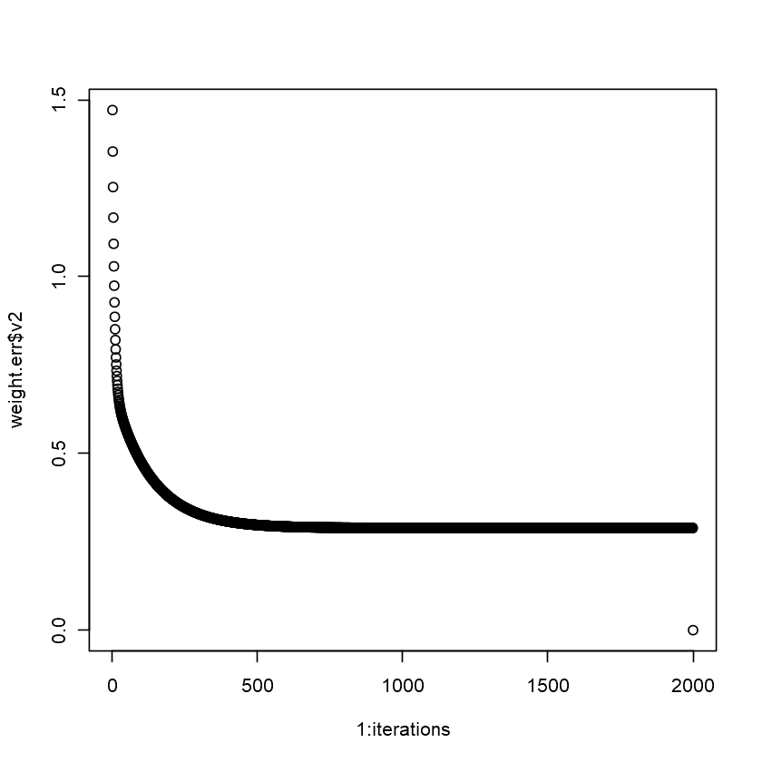

```r
plot(1:iterations,weight.err$v2)
```

From this, we can build a descision surface to classify the instances:

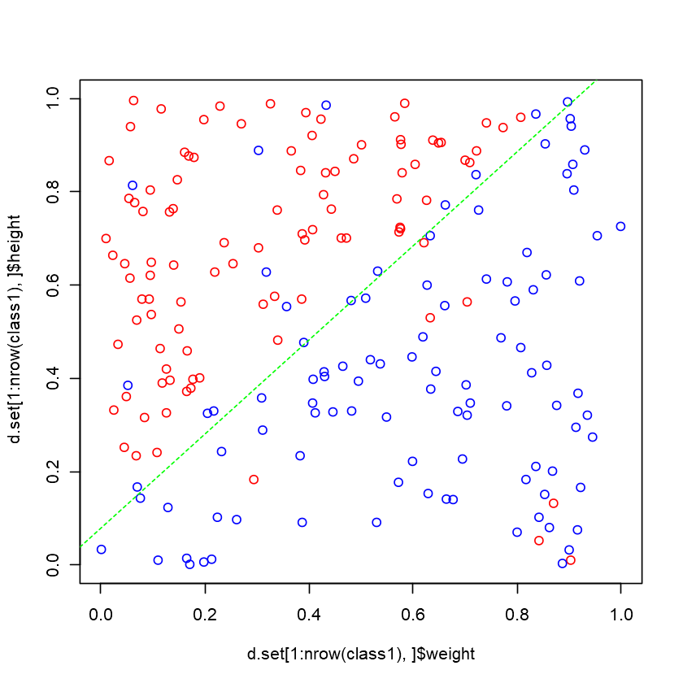

```r
plot(d.set[1:nrow(class1),]$weight,d.set[1:nrow(class1),]$height,xlim=c(0:1),ylim=c(0:1),col="red")
points(d.set[nrow(class1)+1:nrow(class1.2),]$weight,d.set[nrow(class1)+1:nrow(class1.2),]$height,col="blue")
slope<-weight.err$v1[2]/weight.err$v1[3]*(-1)
intercept<-weight.err$v1[1]/weight.err$v1[3]*(-1)
abline(intercept,slope,col="green",lty=2)
```